# Portfolio assignment 2, part 1

MARTIN THOMSEN

14-11-2021

# Exercises and objectives

The objectives of the exercises of this assignment are:  
1) Download and organise the data and model and plot staircase responses based on fits of logistic functions  
2) Fit multilevel models for response times  
3) Fit multilevel models for count data

## Exercise 1

Go to https://osf.io/ecxsj/files/ and download the files associated with Experiment 2 (there should be 29).  
The data is associated with Experiment 2 of the article at the following DOI https://doi.org/10.1016/j.concog.2019.03.007

1. Put the data from all subjects into a single data frame

```r
# Read files and places in dataframe
list_of_files = list.files(path = "experiment_2", pattern = ".csv", full.names = T)
experiment_df = read_csv(list_of_files)
```

2. Describe the data and construct extra variables from the existing variables
   1. add a variable to the data frame and call it *correct* (have it be a *logical* variable). Assign a 1 to each row where the subject indicated the correct answer and a 0 to each row where the subject indicated the incorrect answer (**Hint:** the variable *obj.resp* indicates whether the subject answered “even”, *e* or “odd”, *o*, and the variable *target_type* indicates what was actually presented.

```r
# Create variable and set all to 0
experiment_df$correct = 0

# Loop through data and change "correct" to 1 where response matches target type
for(i in 1:length(experiment_df$trial.type))
{

    if (experiment_df$obj.resp[i]== 'o' && experiment_df$target.type[i] == 'odd')
    {
     experiment_df$correct[i] = 1
    }

    else if(experiment_df$obj.resp[i]== 'e' && experiment_df$target.type[i] == 'even'){
    experiment_df$correct[i] = 1
    }

}

# Set as factor
experiment_df$correct = factor(experiment_df$correct)
```

2. describe what the following variables in the data frame contain, *trial.type*, *pas*, *trial*, *target.contrast*, *cue*, *task*, *target_type*, *rt.subj*, *rt.obj*, *obj.resp*, *subject* and *correct*. (That means you can ignore the rest of the variables in your description). For each of them, indicate and argue for what `class` they should be classified into, e.g. *factor*, *numeric* etc.  
   Trial type: Two different trial types were defined, staircase and experiment. Staircase was utilised to estimate threshold visibility. Based on the staircase results, a target contrast is fixed for use in the experiment setup.

```r
experiment_df$trial.type = factor(experiment_df$trial.type)
```

[output not shown]

```r
experiment_df$cue = factor(experiment_df$cue)
```

[output not shown]

As these experiments are qualitatively different (one cannot expect a linear relationship between performance on the three tasks), it should be factorised.

```r
experiment_df$task = factor(experiment_df$task)
```

```
Target type: Whether the digit presented is odd or even. This is represented in characters as either "odd" or "even". Depending on how this should be handled in further data processing, this could continue to be either characters or a factor. Here it remains characters.
rt.subj: Response time for pressing button following auditory cue. Value is numeric, which is suitable as response time is quantitatively meaningful.
rt.obj: Response time in selecting response based on presented visual cue. Value is numeric, which is suitable as response time is quantitatively meaningful.
obj.resp: Participants response for target type. I.e. if the participant perceives an odd digit, the response would be "o" and if even, "e". This is a character, which could be changed to a factor, if there is a need later on.
subject: Subject identifier.
correct: Whether the participant response (odd or even) matches target type. 1 indicates correct response.Correct is a factor.
```

3. for the staircasing part **only**, create a plot for each subject where you plot the estimated function (on the *target.contrast* range from 0-1) based on the fitted values of a model (use `glm`) that models *correct* as dependent on *target.contrast*. These plots will be our *no-pooling* model. Comment on the fits - do we have enough data to plot the logistic functions?

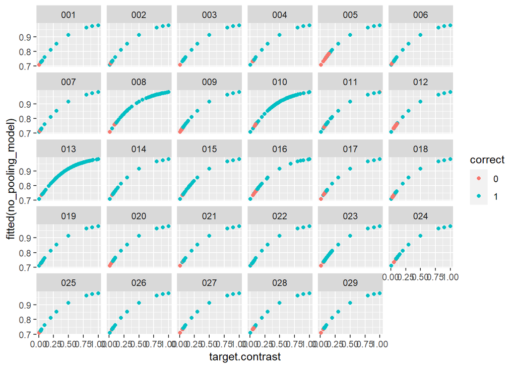

```r
# Creating new dataframe as a subset of original. Selecting only data with trial type "staircase"
staircase_df = subset(experiment_df, experiment_df$trial.type == "staircase")

# Creating no pooling model using glm() function
no_pooling_model = glm(correct ~ target.contrast, data = staircase_df, family = "binomial")

# Plotting using ggplot
ggplot(data = staircase_df, aes(x = target.contrast, y = fitted(no_pooling_model), color = correct)) +
  geom_point() +
  facet_wrap( ~ subject)
```

4. on top of those plots, add the estimated functions (on the *target.contrast* range from 0-1) for each subject based on partial pooling model (use `glmer` from the package `lme4`) where unique intercepts and slopes for *target.contrast* are modelled for each *subject*

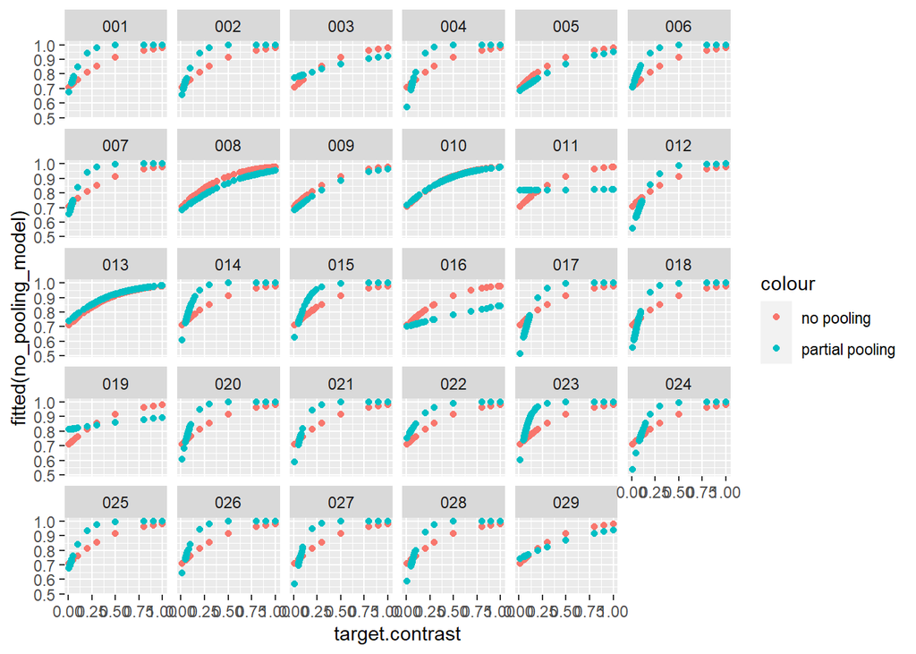

```r
# Creating a pooled model using glm() function
pooled_model = glmer(correct ~ target.contrast + (1+target.contrast|subject), data = staircase_df, family = binomial)

# Plotting using ggplot
ggplot(data = staircase_df) +
  geom_point(aes(x = target.contrast, y = fitted(no_pooling_model), color = "no pooling")) +
  geom_point(aes(x = target.contrast, y = fitted(pooled_model), color = "partial pooling")) +
  facet_wrap( ~ subject)
```

22. in your own words, describe how the partial pooling model allows for a better fit for each subject  
    The first set of plots show how a higher target contrast results in a higher likelihood of a correct answer. When looking at each participant, it appears that the target contrast threshold at which they consistently provide correct answers, is different. Therefore, the partial pooling model will allow for a more accurate fit for each subject, by taking this individual difference into account. ## Exercise 2

Now we **only** look at the *experiment* trials (*trial.type*)

```r
# Creating new dataframe as a subset of original. Selecting only data with trial type "experiment"
trial_df <- subset(experiment_df, experiment_df$trial.type == "experiment")
```

1. Pick four subjects and plot their Quantile-Quantile (Q-Q) plots for the residuals of their objective response times (*rt.obj*) based on a model where only intercept is modelled

```r
# Creating four subsets of data, selecting for subject
subject_1 = subset(trial_df, trial_df$subject == "001")
subject_3 = subset(trial_df, trial_df$subject == "003")
subject_5 = subset(trial_df, trial_df$subject == "005")
subject_7 = subset(trial_df, trial_df$subject == "007")

# Creating a linear model for each selected subject
subject1_model = lm(rt.obj~1, data = subject_1)
subject3_model = lm(rt.obj~1, data = subject_3)
subject5_model = lm(rt.obj~1, data = subject_5)
subject7_model = lm(rt.obj~1, data = subject_7)

# Plotting with qqplot
par(mfrow=c(2,2))
qqPlot(subject1_model)
```

```
## [1]  97 199
```

```r
qqPlot(subject3_model)
```

```
## [1]  64 232
```

```r
qqPlot(subject5_model)
```

```
## [1] 79 88
```

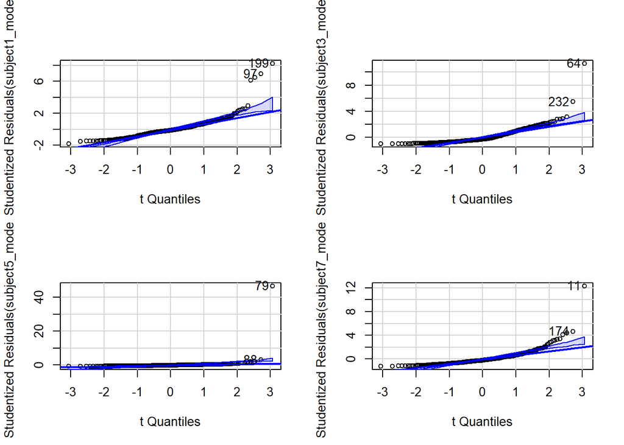

```
## [1]  11 174
```

```r
qqPlot(subject7_model)
```

1. comment on these Each of the four qq-plots show a lack of linearity, with values falling above the normal line at both the low and high end. This is more noticeable for participant 1, 3 and 7, but is also the case for participant 5. As such, the plots indicate that the data are not normally distributed.
2. does a log-transformation of the response time data improve the Q-Q-plots?

```r
# Plotting the log-transformed data. Transformation occurs directly in the model creation
par(mfrow=c(2,2))
qqPlot(lm(log(rt.obj) ~ 1, data = subject_1))
```

```
## [1] 199 347
```

```r
qqPlot(lm(log(rt.obj) ~ 1, data = subject_3))
```

```
## [1]  94 279
```

```r
qqPlot(lm(log(rt.obj) ~ 1, data = subject_5))
```

```
## [1]  79 369
```

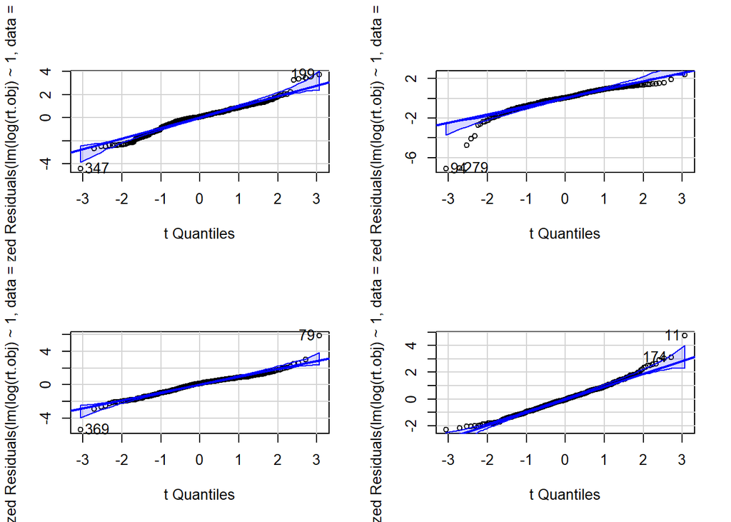

```
## [1]  11 174
```

```r
qqPlot(lm(log(rt.obj) ~ 1, data = subject_7))
```

2. Now do a partial pooling model modelling objective response times as dependent on *task*? (set `REML=FALSE` in your `lmer`-specification)

```r
# Partial pooled model created with subject as random intercept
subject_model = lmer(log(rt.obj) ~ task + (1|subject), data = trial_df, REML = FALSE)

# Partial pooled model including subject and pas as random intercepts
pas_model = lmer(log(rt.obj) ~ task + (1|subject) + (1|pas), data = trial_df, REML = FALSE)

# Partial pooled model including subject and trial as random intercepts
trial_model = lmer(log(rt.obj) ~ task + (1|subject) + (1|trial), data = trial_df, REML = FALSE)

# Combining model names in order to provide a prettier output to reader
models = c("subject_model", "pas_model", "trial_model")

# Compute residual standard deviation and AIC
sigmas = tibble(sigma(subject_model), sigma(pas_model), sigma(trial_model))
Akaike = tibble(AIC(subject_model, pas_model, trial_model))

# Display as combined data
cbind(models, Akaike, sigmas)
```

```
##          models df      AIC sigma(subject_model) sigma(pas_model)
## 1 subject_model  5 29685.31            0.7865108        0.7676126
## 2     pas_model  6 29093.95            0.7865108        0.7676126
## 3   trial_model  6 29459.94            0.7865108        0.7676126
##   sigma(trial_model)
## 1          0.7673537
## 2          0.7673537
## 3          0.7673537
```

```r
## NOTE: Model names have not been changed in order to reflect that these are more complex versions of the ones above.

# Partial pooled model created with a task by subject interaction only
subject_model = lmer(log(rt.obj) ~ task + (1+task|subject), data = trial_df, REML = FALSE)
```

```
## boundary (singular) fit: see ?isSingular
```

```r
# Partial pooled model created with a task by pas interaction in addition to subject as random intercept
pas_model = lmer(log(rt.obj) ~ task + (1+task|pas) + (1|subject), data = trial_df, REML = FALSE)
```

```
## boundary (singular) fit: see ?isSingular
```

```r
# Partial pooled model created with a task by trial interaction in addition to subject as random intercept
trial_model = lmer(log(rt.obj) ~ task + (1+task|trial) + (1|subject), data = trial_df, REML = FALSE)
```

```
## boundary (singular) fit: see ?isSingular
```

```r
# Combining model names in order to provide a prettier output to reader
models = c("subject_model", "pas_model", "trial_model")

# Compute residual standard deviation and AIC
sigmas = tibble(sigma(subject_model), sigma(pas_model), sigma(trial_model))
Akaike = tibble(AIC(subject_model, pas_model, trial_model))

# Display as combined data
cbind(models, Akaike, sigmas)
```

```
##          models df      AIC sigma(subject_model) sigma(pas_model)
## 1 subject_model 10 29560.34            0.7805267        0.7658758
## 2     pas_model 11 29051.91            0.7805267        0.7658758
## 3   trial_model 11 29463.30            0.7805267        0.7658758
##   sigma(trial_model)
## 1          0.7670181
## 2          0.7670181
## 3          0.7670181
```

[output not shown]

```r
# Using the simple pas model
pas_model = lmer(log(rt.obj) ~ task + (1|subject) + (1|pas), data = trial_df, REML = FALSE)
coef(summary(pas_model))
```

```
##                   Estimate Std. Error   t value
## (Intercept)    -0.29543506 0.13400878 -2.204595
## taskquadruplet -0.07863297 0.01680514 -4.679103
## tasksingles    -0.13698236 0.01690658 -8.102310
```

Response times appear to decrease for both quadruplet and single tasks, compared to paired tasks. This is also the case taking subject differences and pas score into account. Compared to pairs task, response times are quite a lot lower for singles (-0.137) and a little lower for quadruplets (-0.079).

3. Now add *pas* and its interaction with *task* to the fixed effects

```r
pas_task_model <- lmer(log(rt.obj) ~ task * pas + (1|subject), data = trial_df, REML = FALSE)
```

```
i. how many types of group intercepts (random effects) can you add without ending up with convergence issues or singular fits?
```

```r
test1 = lmer(log(rt.obj) ~ task * pas + (1|subject)+(1|task), data = trial_df, REML = FALSE) # Is singular
```

```
## boundary (singular) fit: see ?isSingular
```

```r
test2 = lmer(log(rt.obj) ~ task * pas + (1|subject)+(1|trial), data = trial_df, REML = FALSE) # Is fine
test3 = lmer(log(rt.obj) ~ task * pas + (1|subject)+(1|pas), data = trial_df, REML = FALSE) # Is fine
test4 = lmer(log(rt.obj) ~ task * pas + (1|subject)+(1|cue), data = trial_df, REML = FALSE) # Is fine
test5 = lmer(log(rt.obj) ~ task * pas + (1|subject)+(1|trial)+(1|cue), data = trial_df, REML = FALSE) # Is fine
test6 = lmer(log(rt.obj) ~ task * pas + (1|subject)+(1|pas)+(1|cue), data = trial_df, REML = FALSE) # Is fine
test7 = lmer(log(rt.obj) ~ task * pas + (1|subject)+(1|trial)+(1|cue)+(1|pas), data = trial_df, REML = FALSE) # Is fine
test8 = lmer(log(rt.obj) ~ task * pas + (1|subject)+(1|trial)+(1|cue)+(1|pas)+(1|target.contrast), data = trial_df, REML = FALSE) # Failed to converge
```

[output not shown]

```r
print(VarCorr(test1), comp='Variance')
```

```
##  Groups   Name        Variance
##  subject  (Intercept) 0.16206
##  task     (Intercept) 0.00000
##  Residual             0.60100
```

```
iii. in your own words - how could you explain why your model would result in a singular fit?
```

It appears that task accounts for 0 of the variance, which explains the singular fit.

## Exercise 3

1. Initialise a new data frame, `data.count`. *count* should indicate the number of times they categorized their experience as *pas* 1-4 for each *task*. I.e. the data frame would have for subject 1: for task:singles, pas1 was used # times, pas2 was used # times, pas3 was used # times and pas4 was used # times. You would then do the same for task:pairs and task:quadruplet

```r
# Grouping data by subject, task and pas and counting each occurence of each combination
# For each subject there are three tasks and at most four pas scores, resulting in no more than 12 counts per subject
data.count <- trial_df %>%
  group_by(subject, task, pas) %>%
  dplyr::summarise("count" = n())
data.count$pas = factor(data.count$pas)
```

2. Now fit a multilevel model that models a unique “slope” for *pas* for each *subject* with the interaction between *pas* and *task* and their main effects being modelled

```r
# Model with a pas by task interaction (pas*task) and a slope for pas for each subject (pas|subject)
count_model = glmer(count ~ pas * task + (pas|subject), data = data.count, family = poisson)
```

[output not shown]

```r
# New algorithm
count_model = glmer(count ~ pas * task + (pas|subject), data = data.count, family = poisson, control = glmerControl(optimizer="bobyqa"))
```

```
iv. when you have a converging fit - fit a model with only the main effects of _pas_ and _task_. Compare this with the model that also includes the interaction
```

```r
null_model <- glmer(count ~ 1 + (pas|subject), data = data.count, family = poisson)
pas_task_model <- glmer(count ~ pas + task + (pas|subject), data = data.count, family = poisson, control = glmerControl(optimizer="bobyqa"))

# Combining model names in order to provide a prettier output to reader
models = c("null_model", "pas_task_model", "count_model")

# Compute residual standard deviation and AIC
sigmas = tibble(sigma(null_model), sigma(pas_task_model), sigma(count_model))
Akaike = tibble(AIC(null_model, pas_task_model, count_model))

# Display as combined data
cbind(models, Akaike, sigmas)
```

```
##           models df      AIC sigma(null_model) sigma(pas_task_model)
## 1     null_model 11 2929.844                 1                     1
## 2 pas_task_model 16 2933.264                 1                     1
## 3    count_model 22 2778.987                 1                     1
##   sigma(count_model)
## 1                  1
## 2                  1
## 3                  1
```

[output not shown]

```r
coef(summary(count_model))
```

```
##                        Estimate Std. Error    z value      Pr(>|z|)
## (Intercept)          3.61414429 0.14254409 25.3545715 8.001555e-142
## pas2                -0.04097441 0.15647263 -0.2618631  7.934270e-01
## pas3                -0.37076428 0.20907181 -1.7733824  7.616536e-02
## pas4                -0.94170145 0.37739151 -2.4952905  1.258541e-02
## taskquadruplet       0.06070920 0.03731592  1.6268981  1.037588e-01
## tasksingles         -0.23490313 0.04030734 -5.8278001  5.616278e-09
## pas2:taskquadruplet -0.04411161 0.05519583 -0.7991837  4.241839e-01
## pas3:taskquadruplet -0.11069239 0.06364845 -1.7391217  8.201336e-02
## pas4:taskquadruplet -0.11778598 0.06278750 -1.8759464  6.066264e-02
## pas2:tasksingles     0.17453952 0.05783077  3.0181080  2.543583e-03
## pas3:tasksingles     0.23754071 0.06457319  3.6786276  2.344924e-04
## pas4:tasksingles     0.59797420 0.06097590  9.8067295  1.053270e-22
```

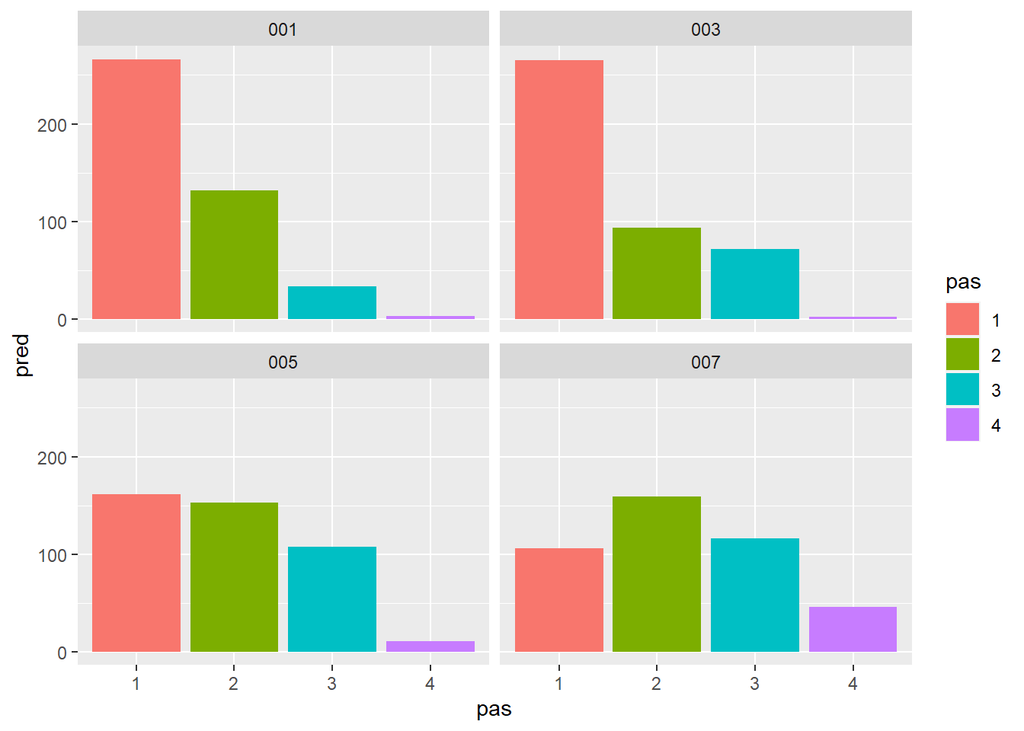

```r
# Creating subset including four subjects
data.count_subjects = filter(data.count, subject == "001" | subject == "003" | subject == "005" | subject == "007")

# Modelling predicted values and setting as a new variable in data frame
data.count_subjects$pred = exp(predict(count_model, newdata = data.count_subjects))

# Plotting with ggplot
ggplot(data.count_subjects, aes(x = pas, y = pred, fill = pas)) +
  geom_bar(stat = 'identity') +
  facet_wrap(~ subject)
```

3. Finally, fit a multilevel model that models *correct* as dependent on *task* with a unique intercept for each *subject*

```r
correct_model_1 = glmer(correct ~ task + (1|subject), data = trial_df, family = binomial)
coef(summary(correct_model_1))
```

```
##                   Estimate Std. Error   z value     Pr(>|z|)
## (Intercept)     1.11895699 0.11765673  9.510353 1.900168e-21
## taskquadruplet -0.07495728 0.05080445 -1.475408 1.401029e-01
## tasksingles     0.16603081 0.05217255  3.182340 1.460900e-03
```

```
i. does _task_ explain performance?
Yes. The rate of correct answers increase from pairs task to singles tasks and decreases from pairs task to quadruplet task, congruent with the above. The p-values, however, indicates that the decrease in correct answers in quadruplet tasks is insignificant (p>0.05).
ii. add _pas_ as a main effect on top of _task_ - what are the consequences of that?
```

```r
correct_model_2 = glmer(correct ~ task +  pas + (1|subject), data = trial_df, family = binomial)
coef(summary(correct_model_2))
```

```
##                   Estimate Std. Error    z value      Pr(>|z|)
## (Intercept)    -0.81546546 0.11201051 -7.2802582  3.331819e-13
## taskquadruplet -0.02632515 0.05371792 -0.4900627  6.240896e-01
## tasksingles    -0.03491715 0.05568907 -0.6270019  5.306580e-01
## pas             0.94640589 0.02787707 33.9492563 1.250968e-252
```

The intercept value drops and both quadruplet and singles tasks show worse rate of correct answers compaired to pairs. However, the changes with task are both insignificant. Instead, pas accounts for a significant amount of the esimate, while being significant (p<<0.01). iii. now fit a multilevel model that models *correct* as dependent on *pas* with a unique intercept for each *subject*

[output not shown]

```r
correct_model_4 = glmer(correct ~ pas * task + (1|subject), data = trial_df, family = binomial)
coef(summary(correct_model_4))
```

```
##                       Estimate Std. Error    z value     Pr(>|z|)
## (Intercept)        -0.78551974 0.12836170 -6.1195803 9.382215e-10
## pas                 0.92984185 0.04473948 20.7834761 6.107263e-96
## taskquadruplet      0.06802579 0.11903246  0.5714894 5.676679e-01
## tasksingles        -0.22299738 0.12459616 -1.7897613 7.349229e-02
## pas:taskquadruplet -0.05407842 0.05987594 -0.9031745 3.664333e-01
## pas:tasksingles     0.09904322 0.06039581  1.6399022 1.010255e-01
```

```
v. describe in your words which model is the best in explaining the variance in accuracy
It is clear from models 1 and 2 that pas is the better variable for explaining variance, compared to tasks. Model 3 confirms this. Model 4 provides even more evidence of this, as only pas is a significant contributor of variance. As such, the model correct ~ pas + (1|subject) is the superior model.
```